# Dummy Variables and Non-Linear Models

Prof. Caraher

Colby College

Oct 26, 2026

## Roadmap

- **Where we are:** we can estimate multivariate regressions, interpret them, and test hypotheses. Now we make our models more **flexible**
- **Running example:** the **gender wage gap**, measured with real data on 20,000 U.S. workers

|  | The question | The tool |
| --- | --- | --- |
| 1 | How much less do women earn than men? | **Dummy variables** |
| 2 | How do we compare five race and ethnicity groups? | **Multiple categories** |
| 3 | How big is the gap in **percent**? | **Logs** |
| 4 | How do wages grow over a career? | **Quadratics** |
| 5 | What gap is left when we hold everything constant? | **Putting it all together** |

## The Gender Wage Gap

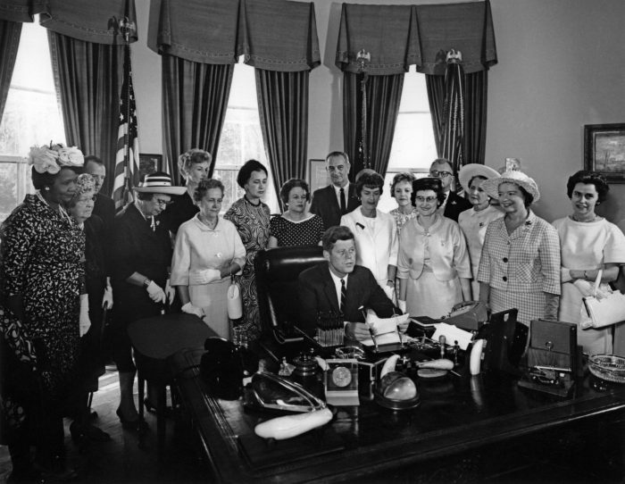

President Kennedy signs the Equal Pay Act, June 10, 1963

- The **gender wage gap**: how much less women earn than men, usually reported as women’s pay as a **share** of men’s pay
- **1963:** The Equal Pay Act bans paying women less than men for equal work. Kennedy: “the average woman worker earns only 60 percent of the average wage for men”
- **2025:** Among full-time, year-round workers, women’s median earnings were **83.9%** of men’s, about 84 cents on the dollar

Photo: Abbie Rowe, White House Photographs, JFK Presidential Library (public domain). 2025 figure: U.S. Census Bureau (2026), *Income in the United States: 2025*.

## The Gap Over Time

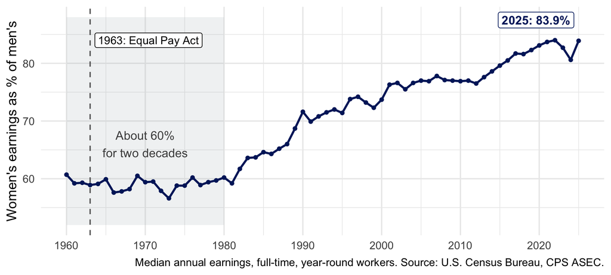

- Stuck near 60% until 1980, rapid catch-up in the 1980s, slower gains since
- Why is there still a gap? Research points to differences in **jobs**, **hours**, and what happens after **children** arrive. We’ll come back to each one

# Measuring the Gap: Dummy Variables

Suppose we want to measure the gender wage gap ourselves. How do we do it?

## Our Data: The American Community Survey

- First, we need data on workers’ **wages** and **sex**
- Each year the Census Bureau’s **American Community Survey** (ACS) samples about 3.5 million U.S. addresses
- We use **20,000 full-time, year-round workers** ages 25–64 from the **2024 ACS** (`data/acs_wages/`)

```r
acs <- read_csv("data/acs_wages/acs_wages.csv")
```

```r
acs |> select(wage, educ, exper, sex, race_eth) |> head(5)
```

```
# A tibble: 5 × 5
   wage  educ exper sex   race_eth
  <dbl> <dbl> <dbl> <chr> <chr>
1  26.4    13    41 Male  Hispanic
2  47.8    16    30 Male  White
3  19.5     9    15 Male  Hispanic
4  24.4    12    36 Male  White
5  27.3    12    38 Male  Black
```

- `wage` is the **hourly** wage ($): annual earnings ÷ (weekly hours × weeks worked)
- `sex` and `race_eth` are **words**, not numbers. How do we put them in a regression?

## What Are Dummy Variables?

- So far we’ve used **quantitative** variables: wages, education, experience…
- But many important variables are **qualitative**: sex, race, region, marital status, program participation
- A **dummy variable** (aka indicator or binary variable) translates **qualitative info into numbers**:

$$D = \begin{cases} 1 & \text{if the characteristic is present} \\ 0 & \text{otherwise} \end{cases}$$

- To measure the gender gap, we recode `sex` as a dummy:

$$female_i = \begin{cases} 1 & \text{if worker $i$ is a woman} \\ 0 & \text{otherwise} \end{cases}$$

- Other examples: $married = 1$ if married, $south = 1$ if in the South, $treated = 1$ if in the treatment group (we have seen this one before!)

## Creating a Dummy Variable with `case_when()`

```r
case_when(
  condition1 ~ value1,
  condition2 ~ value2,
  TRUE       ~ default_value
)
```

- Each line is a **condition ~ value** pair, checked top to bottom
- `TRUE ~ ...` is a catch-all “else”
- Careful: `TRUE ~ 0` also turns **missing** values into 0

```r
acs <- acs |>
  mutate(female = case_when(
    sex == "Female" ~ 1,
    sex == "Male"   ~ 0
  ))

# check: every "Female" is a 1 and every "Male" is a 0
acs |> count(sex, female)
```

```
# A tibble: 2 × 3
  sex    female     n
  <chr>   <dbl> <int>
1 Female      1  9113
2 Male        0 10887
```

## The Raw Gap: Regression on a Dummy

To estimate the gender wage gap, we simply include the dummy on the right-hand side:

$$wage = \beta_0 + \beta_1(female) + \mu$$

```r
lm_raw <- lm(wage ~ female, data = acs)
coef(lm_raw) |> round(2)
```

```
(Intercept)      female
      44.53       -8.82
```

- **Men** ($female = 0$): $\widehat{wage} = \hat{\beta}_0 = 44.53$
- **Women** ($female = 1$): $\widehat{wage} = \hat{\beta}_0 + \hat{\beta}_1 = 44.53 - 8.82 = 35.71$
- $\hat{\beta}_1 \approx -8.82$: on average, women earn **$8.82/hr less** than men, the **raw** gap

```r
acs |> group_by(sex) |> summarize(avg_wage = mean(wage))
```

```
# A tibble: 2 × 2
  sex    avg_wage
  <chr>     <dbl>
1 Female     35.7
2 Male       44.5
```

- Why does this work? One dummy just compares **group means**: $\hat{\beta}_0$ = the baseline group’s average, $\hat{\beta}_1$ = the difference

## Adjusting for Differences

- The premise of the Equal Pay Act is that firms can’t discriminate between workers at the same job with equal qualifications
- So to measure the gender wage gap, we need to make sure we have an **apples-to-apples** (or ceteris paribus) comparison. How do we do that?
- We can use **multivariate OLS** to help ensure we are controlling for differences between men and women in terms of education, experience, etc.

## The Adjusted Gap: Holding Education Constant

Let’s start with an estimate of the wage gap **controlling for education**. Add $educ$:

$$wage = \beta_0 + \beta_1(female) + \beta_2(educ) + \mu$$

```r
lm_educ <- lm(wage ~ female + educ, data = acs)
printCoefmat(coef(summary(lm_educ)), digits = 3)
```

```
            Estimate Std. Error t value Pr(>|t|)
(Intercept) -18.9090     1.1946   -15.8   <2e-16 ***
female      -11.6687     0.4834   -24.1   <2e-16 ***
educ          4.4522     0.0807    55.2   <2e-16 ***
---
Signif. codes:  0 '***' 0.001 '**' 0.01 '*' 0.05 '.' 0.1 ' ' 1
```

- $\hat{\beta}_1 \approx -11.67$: with the **same education**, women earn $11.67/hr less than men
- Why is the gap **bigger** than the raw gap? Women in our data have **more** schooling (14.9 vs. 14.2 years), so leaving education out **hid** part of the gap: omitted variable bias!

**Adjusted Gap ≠ Discrimination**

$\hat{\beta}_1$ compares men and women who are alike in the ways **we measure**. Unmeasured differences (and which controls we choose) change the answer.

## What Dummies Do: A Picture

- Dummy variables essentially give each group its **own intercept**, but the same slope

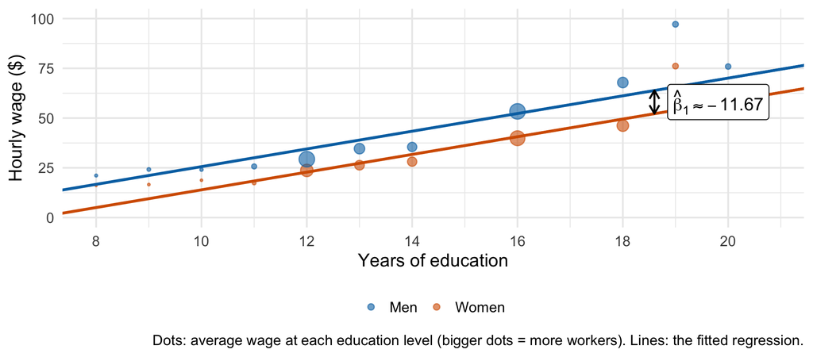

## The Dummy Variable Trap

Why not include dummies for **both** groups?

$$wage = \beta_0 + \beta_1(female) + \beta_2(male) + \beta_3(educ) + \mu$$

- For every worker: $female + male = 1$, so $male = 1 - female$
- $male$ is an exact linear function of the intercept’s “1” and $female$: **perfect multicollinearity**

```r
acs <- acs |> mutate(male = 1 - female)
lm(wage ~ female + male + educ, data = acs) |> coef() |> round(2)
```

```
(Intercept)      female        male        educ
     -18.91      -11.67          NA        4.45
```

- R won’t give an error: `lm()` silently drops one and reports its coefficient as `NA`

**The Rule**

Always **omit one group** when including dummy variables. The omitted category is the **baseline** (reference group).

## Multiple Categories: Race and Ethnicity

- Now suppose we want to compare workers by **race and ethnicity**. How many groups does `race_eth` have?
- **Five.** With $g$ categories, we create $g - 1$ dummies, so we need **four**

```r
acs |> count(race_eth)
```

```
# A tibble: 5 × 2
  race_eth     n
  <chr>    <int>
1 Asian     1473
2 Black     2014
3 Hispanic  3433
4 Other      944
5 White    12136
```

```r
acs <- acs |>
  mutate(black    = case_when(race_eth == "Black"    ~ 1, TRUE ~ 0),
         hispanic = case_when(race_eth == "Hispanic" ~ 1, TRUE ~ 0),
         asian    = case_when(race_eth == "Asian"    ~ 1, TRUE ~ 0),
         other    = case_when(race_eth == "Other"    ~ 1, TRUE ~ 0))

acs |> distinct(race_eth, black, hispanic, asian, other) |> arrange(race_eth)
```

```
# A tibble: 5 × 5
  race_eth black hispanic asian other
  <chr>    <dbl>    <dbl> <dbl> <dbl>
1 Asian        0        0     1     0
2 Black        1        0     0     0
3 Hispanic     0        1     0     0
4 Other        0        0     0     1
5 White        0        0     0     0
```

- Each group gets its own pattern of 1s and 0s. White workers have all four dummies = 0: they are the **baseline**

## Interpreting: Relative to the Baseline

$$wage = \beta_0 + \beta_1(female) + \beta_2(educ) + \beta_3(black) + \beta_4(hispanic) + \beta_5(asian) + \beta_6(other) + \mu$$

```r
lm_race <- lm(wage ~ female + educ + black + hispanic + asian + other, data = acs)
coef(lm_race) |> round(2)
```

```
(Intercept)      female        educ       black    hispanic       asian
     -14.79      -11.19        4.21       -7.67       -3.47        9.57
      other
      -3.53
```

- Interpret dummy variables with multiple categories **relative to the omitted category (i.e., the baseline)**
- $\hat{\beta}_3 \approx -7.67$: Black workers earn $7.67/hr less than **White** workers *of the same sex and education*
- $\hat{\beta}_5 \approx 9.57$: Asian workers earn $9.57/hr more than **White** workers, holding sex and education constant
- The gender gap barely moves: $\hat{\beta}_1 \approx -11.19$ (it was $-11.67$)

## Factor Variables and Changing the Baseline

- R creates the dummies for you when a variable is text or a **factor**:

```r
lm(wage ~ female + educ + race_eth, data = acs) |> coef() |> round(2)
```

```
     (Intercept)           female             educ    race_ethBlack
           -5.22           -11.19             4.21           -17.24
race_ethHispanic    race_ethOther    race_ethWhite
          -13.04           -13.10            -9.57
```

- R’s baseline is the **first level** (alphabetical): **Asian**. Every race coefficient is now relative to Asian workers!

```r
acs <- acs |> mutate(race_eth = relevel(factor(race_eth), ref = "White"))
lm(wage ~ female + educ + race_eth, data = acs) |> coef() |> round(2)
```

```
     (Intercept)           female             educ    race_ethAsian
          -14.79           -11.19             4.21             9.57
   race_ethBlack race_ethHispanic    race_ethOther
           -7.67            -3.47            -3.53
```

- Same as our hand-made dummies. The baseline doesn’t change `female`, `educ`, $R^2$, or the gaps **between** groups (Asian − Black = $9.57 - (-7.67) = 17.24$ either way)
- **Practical advice:** pick the baseline that matches the comparison you want (e.g., men for the gender gap)

# Log Wages: The Gap in Percent

Suppose we want to measure the gap in **percent** instead of dollars. How do we do it?

## Why Log Wages?

- Wages are **right-skewed**: the middle half of workers earn $21–$48 an hour, but 254 of the 20,000 earn more than $200
- Logging compresses the right tail → a more symmetric distribution

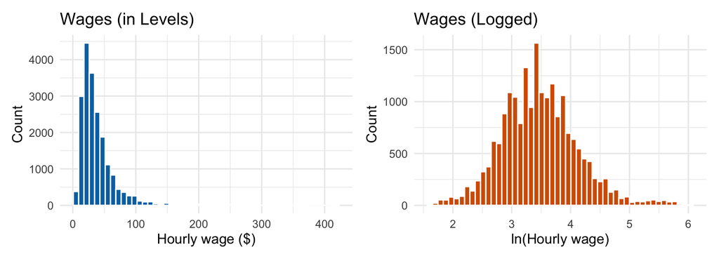

- More importantly: a $8.82 gap is **huge** for a $20/hr worker but **small** for a $100/hr worker. Logs let us measure gaps in **percent**

## From Logs to Percent Changes

We need one key property of logs:

$$\ln(Y_1) - \ln(Y_0) = \ln\!\left(\frac{Y_1}{Y_0}\right) \approx \frac{Y_1 - Y_0}{Y_0}$$

A **difference in logs** $\approx$ the **proportional change** (for small changes) [see lecture notes for full proof]

| Wage Change | Proportional Change | Difference in Logs |
| --- | --- | --- |
| $20 → $21 | $1/20 = 0.050$ | $\ln(21)-\ln(20) = 0.049$ |
| $20 → $22 | $2/20 = 0.100$ | $\ln(22)-\ln(20) = 0.095$ |
| $20 → $25 | $5/20 = 0.250$ | $\ln(25)-\ln(20) = 0.223$ |
| $20 → $50 | $30/20 = 1.500$ | $\ln(50)-\ln(20) = 0.916$ |

Works well for small changes; it breaks down for large ones

## Interpreting the Log-Level Model

$$\ln(Y) = \beta_0 + \beta_1 X + \mu$$

What happens when $X$ increases by one unit?

**Steps 1–2:** Write the model at $X_0 + 1$ and $X_0$, then subtract:

$$\ln(Y_1) - \ln(Y_0) = [\beta_0 + \beta_1(X_0 + 1)] - [\beta_0 + \beta_1 X_0] = \beta_1$$

**Steps 3–4:** Apply the approximation, then multiply by 100:

$$\frac{Y_1 - Y_0}{Y_0} \approx \beta_1 \quad \Rightarrow \quad \text{% change in } Y \approx 100 \times \beta_1$$

**Log-Level Interpretation**

A **one-unit** increase in $X$ → approximately $100 \times \beta_1$ **percent** change in $Y$

If $X$ is a **dummy**, $100 \times \beta_1$ is the approximate **percent difference** from the baseline group

For big coefficients (roughly $|\beta_1| > 0.20$), use the exact formula: $100 \times (e^{\beta_1} - 1)$ percent

## The Gender Gap in Percent

$$\ln(wage) = \beta_0 + \beta_1(female) + \mu$$

```r
acs <- acs |> mutate(log_wage = log(wage))
lm(log_wage ~ female, data = acs) |> coef() |> round(3)
```

```
(Intercept)      female
      3.547      -0.173
```

- Women earn about **17.3% less** than men ($100 \times \hat{\beta}_1$)
- $|\hat{\beta}_1|$ is close to 0.20, so check the exact formula: $100 \times (e^{-0.173} - 1) = -15.9\%$, so women earn **15.9% less**
- $e^{\hat{\beta}_1} = 0.84$: women’s (geometric) average **hourly** wage is 84% of men’s. Their median **annual** earnings are only 80% of men’s, partly because men work more hours

## Adding Education: The Return to Schooling

```r
lm(log_wage ~ female + educ, data = acs) |> coef() |> round(3)
```

```
(Intercept)      female        educ
      2.097      -0.239       0.102
```

- Same education: $100 \times (e^{-0.239} - 1) = -21.3\%$, so women earn **21.3% less** than men
- Each extra year of school → about **10% higher** wages: the **return to schooling**

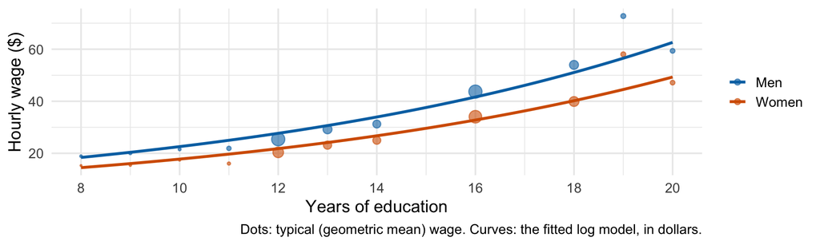

- A constant **percent** return is a **curve** in dollars, and a constant **percent** gap is more dollars at higher wages: the lines are no longer parallel

## Other Log Models

| Model | Equation | $X$ changes by… | $Y$ changes by… |
| --- | --- | --- | --- |
| **Level-Level** | $Y = \beta_0 + \beta_1 X$ | 1 unit | $\beta_1$ units |
| **Log-Level** | $\ln(Y) = \beta_0 + \beta_1 X$ | 1 unit | $(100\beta_1)$% |
| **Level-Log** | $Y = \beta_0 + \beta_1\ln(X)$ | 1% | $\beta_1/100$ units |
| **Log-Log** | $\ln(Y) = \beta_0 + \beta_1\ln(X)$ | 1% | $\beta_1$% |

**Quick Rule**

- **Logged** variable → think in **percents**
- **Level** variable → think in **units**

## Log Models: Examples

Suppose we want to know how annual **earnings** change with weekly **hours** (our ACS data):

**Level-Log**

$\widehat{earnings} = -434{,}276 + 140{,}104 \cdot \ln(hours)$

Formula: $\Delta Y = \frac{\beta_1}{100} \cdot \%\Delta X$

$\Delta earnings = \frac{140{,}104}{100} \cdot 1 \approx \$1{,}401$

1% more weekly hours → about **$1,401 more** per year

**Log-Log**

$\widehat{\ln(earnings)} = 6.58 + 1.22 \cdot \ln(hours)$

Formula: $\%\Delta Y = \beta_1 \cdot \%\Delta X$

$\%\Delta earnings = 1.22 \cdot 1 = 1.22\%$

1% more weekly hours → **1.22%** higher earnings

$\beta_1$ is the **elasticity**: a unit-free measure of responsiveness

## When to Use Logs?

**Commonly logged:**

- Wages, income, prices, population, firm revenue, expenditures
- Positive, right-skewed, where % changes are more meaningful

**Typically NOT logged:**

- Education (years), age, experience, rates/percentages, dummy variables
- Variables that can be zero or negative ($\ln(0)$ is undefined!)

**Watch Out**

1. The “$100 \times \beta_1$%” approximation works for small $\beta_1$ (roughly $|\beta_1| < 0.20$). For larger coefficients, use the **exact** formula: $100 \times (e^{\beta_1} - 1)$%
2. Be wary if your pre-logged variable contains negative numbers or zeros! (Our data only include workers with positive wages.)

## Practice: Log Models

Name the model and interpret $\hat{\beta}_1$:

1. $\ln(\widehat{wage}) = 0.58 + 0.083 \cdot educ$ (1976 workers, `wage1`)
2. $\widehat{price} = -595.44 + 99.83 \cdot \ln(lotsize)$, price in $1,000s (houses, `hprice1`)
3. $\ln(\widehat{salary}) = 4.82 + 0.257 \cdot \ln(sales)$ (CEOs, `ceosal1`)
4. $\ln(\widehat{wage}) = 3.31 + 0.266 \cdot married$ (our ACS data)

**Answers:**

1. **Log-level:** 1 more year of school → ≈ **8.3%** higher wage
2. **Level-log:** 1% larger lot → $99.83/100 \approx 0.998$ thousand, so about **$998** higher price
3. **Log-log:** 1% more sales → **0.257%** higher salary (an elasticity)
4. **Log-level, dummy:** married workers earn ≈ 26.6% more; $\hat{\beta}_1 > 0.20$, so exact: $100 \times (e^{0.266} - 1) =$ **30.5%**

# Experience: Non-Linear Models

Suppose we want to know how wages grow over a career. How do we do it?

## Why Non-Linear?

- Linear models assume a **constant** marginal effect: every extra year of experience raises wages by the same amount
- But many relationships curve:
  - **Experience → wages:** rise fast early, then flatten (and may fall near retirement). **Human capital theory** (Mincer 1974): workers invest in skills early in their careers
  - **Temperature → electricity demand:** high when it’s cold *and* when it’s hot (U-shape)
  - **Advertising → sales:** diminishing returns
- We can capture this with a **quadratic** (polynomial) model:

$$Y = \beta_0 + \beta_1 X + \beta_2 X^2 + \mu$$

- $\beta_2 < 0$: inverted-U (wages & experience)
- $\beta_2 > 0$: U-shape (electricity demand & temperature)

## Estimating a Quadratic

$$\ln(wage) = \beta_0 + \beta_1(exper) + \beta_2(exper^2) + \mu$$

$exper$ is **potential experience**, the years since leaving school: $exper = age - educ - 6$ (the ACS doesn’t ask about work history)

**Key idea:** create a new variable $exper^2$ and include it as an additional regressor

**Step 1:** Keep workers with a bachelor’s degree (this holds education fixed), then create the squared term

```r
ba <- acs |>
  filter(degree == "Bachelor's") |>
  mutate(exper2 = exper^2)
```

**Step 2:** Run OLS with both $exper$ and $exper^2$

```r
lm_quad <- lm(log_wage ~ exper + exper2, data = ba)
coef(lm_quad) |> round(6)
```

```
(Intercept)       exper      exper2
   3.326782    0.028809   -0.000461
```

- $\hat{\beta}_1 > 0$ and $\hat{\beta}_2 < 0$ → inverted-U confirmed!
- This is still OLS: we just added $X^2$ as another variable

## Visualizing the Quadratic Fit

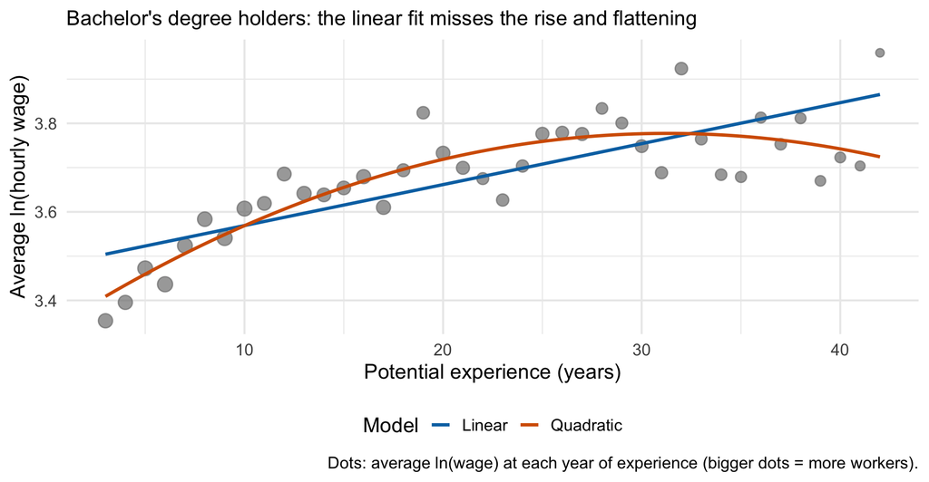

## Interpreting Quadratics

The marginal effect of $X$ on $Y$ is **not constant**: it depends on $X$

$$\frac{\partial Y}{\partial X} = \beta_1 + 2\beta_2 X$$

With $\hat{\beta}_1 \approx 0.0288$ and $\hat{\beta}_2 \approx -0.000461$ (and $Y = \ln(wage)$, so we multiply by 100 to get %):

| Experience | Marginal Effect (%) | Interpretation |
| --- | --- | --- |
| 5 years | $100 \times [0.0288 + 2(-0.000461)(5)] = 2.4$ | $+2.4$% per extra year |
| 20 years | $100 \times [0.0288 + 2(-0.000461)(20)] = 1.0$ | $+1.0$% per extra year |
| 35 years | $100 \times [0.0288 + 2(-0.000461)(35)] = -0.3$ | $-0.3$% per extra year (past the peak) |

**Peak:** $x^* = -\frac{\beta_1}{2\beta_2} = -\frac{0.0288}{2(-0.000461)} \approx 31$ years

# Putting It All Together

Suppose we want to hold **everything** constant at once. How do we do it?

## Why Control for Everything?

- **Remember the goal:** the Equal Pay Act requires equal pay for **equal work** (jobs requiring equal skill, effort, and responsibility). To measure the gap, we want an **apples-to-apples** (ceteris paribus) comparison
- Men and women differ in ways that also affect wages: education, experience, race/ethnicity, occupation, hours…
- If a variable affects wages **and** differs between men and women, leaving it out mixes its effect into the “gap”: **omitted variable bias**
- We saw this with education: women have **more** schooling, so the raw gap ($8.82/hr) **understated** the gap between equally educated men and women ($11.67/hr)

## What Could We Control For?

**In our ACS data**

- Education and potential experience
- Race and ethnicity (5 groups)
- Marital status
- Occupation (22 groups)
- State (51) → **region** of the country
- Usual weekly hours

**Not in our data** (richer data sets have them)

- **Industry** (e.g., retail vs. finance)
- Actual years of work experience
- Children
- Union membership
- The employer itself
- College major
- Many controls are **categories** with **many groups**. Make them **factors** with `as.factor()`, and `lm()` turns each one into $g - 1$ dummies, dropping a baseline for us (no dummy trap):

```r
# state and occ_group are text (character vectors): make them factors
acs <- acs |> mutate(state = as.factor(state), occ_group = as.factor(occ_group))
m_big <- lm(log_wage ~ female + educ + occ_group + state, data = acs)
length(coef(m_big))   # intercept + female + educ + 21 occupation + 50 state dummies
```

```
[1] 74
```

- `as.factor()` matters most when groups are stored as **numbers** (e.g., state codes 1–56): otherwise R treats them as one continuous variable!

## How to Read a Regression Table

|  | (1) | (2) |
| --- | --- | --- |
| Female | -0.173*** | -0.239*** |
|  | (0.009) | (0.008) |
| Years of education |  | 0.102*** |
|  |  | (0.001) |
| Constant | 3.547*** | 2.097*** |
|  | (0.006) | (0.020) |
| Num.Obs. | 20000 | 20000 |
| R2 | 0.018 | 0.238 |

* p < 0.1, ** p < 0.05, *** p < 0.01  
Outcome: ln(hourly wage). Standard errors in parentheses.

- **Columns:** each column is a different **regression**. (1) is the raw gap; (2) adds education. Side by side, we see how $\hat{\beta}$ **changes** as we add controls
- **Rows:** one per regressor. The top number is $\hat{\beta}_j$; the number in **parentheses** is its **standard error**
- **Stars:** significance levels, defined in the **notes** at the bottom
- **Blank cell:** that variable is **not in** that regression
- **Bottom rows:** sample size ($N$) and $R^2$

**Common Mistakes When Reading Tables**

Parentheses hold **standard errors**, not t-statistics or confidence intervals. Stars are not **practical** significance: always look at the **size** of $\hat{\beta}_j$

## The Adjusted Gap: Holding Everything Constant

|  | (1) | (2) | (3) | (4) | (5) |
| --- | --- | --- | --- | --- | --- |
| Female | -0.173*** | -0.239*** | -0.238*** | -0.228*** | -0.191*** |
|  | (0.009) | (0.008) | (0.008) | (0.008) | (0.008) |
| Years of education |  | 0.102*** | 0.112*** | 0.107*** | 0.082*** |
|  |  | (0.001) | (0.001) | (0.001) | (0.002) |
| Potential experience |  |  | 0.019*** | 0.020*** | 0.022*** |
|  |  |  | (0.001) | (0.001) | (0.001) |
| Potential experience² / 100 |  |  | -0.023*** | -0.025*** | -0.027*** |
|  |  |  | (0.003) | (0.003) | (0.003) |
| Black |  |  |  | -0.187*** | -0.133*** |
|  |  |  |  | (0.013) | (0.012) |
| Hispanic |  |  |  | -0.088*** | -0.052*** |
|  |  |  |  | (0.011) | (0.010) |
| Asian |  |  |  | 0.131*** | 0.093*** |
|  |  |  |  | (0.015) | (0.014) |
| Other race/ethnicity |  |  |  | -0.065*** | -0.053*** |
|  |  |  |  | (0.019) | (0.017) |
| Occupation dummies (22 groups) |  |  |  |  | Yes |
| Num.Obs. | 20000 | 20000 | 20000 | 20000 | 20000 |
| R2 | 0.018 | 0.238 | 0.262 | 0.275 | 0.379 |

* p < 0.1, ** p < 0.05, *** p < 0.01  
Outcome: ln(hourly wage). Race/ethnicity baseline: White. Standard errors in parentheses.

## What the Table Tells Us

- **The gender gap** depends on what we hold constant: 15.9% raw (1), 21.3% with the same education (2), and 20.4% with the same education, potential experience (≈ age), and race/ethnicity (4)
- **The other rows** answer other questions. In column (4):
  - Each extra year of school → about **11%** higher wages
  - Experience: $+$ on the linear term, $-$ on the squared term → wages rise with experience, but more and more slowly
  - Black workers earn **17.1%** less than White workers of the same sex, education, and experience; Asian workers earn **14.0%** more
- **Same occupation** too (5): 17.4% less. Occupation and industry are also the largest measured factors nationally (Blau & Kahn 2017). But should we control for occupation? What if women are steered away from higher-paying jobs?
- $R^2$ climbs from 0.02 to 0.38, but a high $R^2$ isn’t the goal: we care about the coefficient on $female$

## Key Takeaways

- **Dummy variables:** shift the intercept; each coefficient is the gap from the omitted **baseline** ($g$ groups → $g - 1$ dummies)
- **Log-level:** 1-unit ↑ $X$ → ≈ $100\beta_1$% change in $Y$; for big $\beta_1$, use $100(e^{\beta_1} - 1)$%. For a dummy, it’s the % gap from the baseline
- **Level-log:** 1% ↑ $X$ → $\beta_1/100$-unit change in $Y$
- **Log-log:** 1% ↑ $X$ → $\beta_1$% change in $Y$ (an **elasticity**)
- **Quadratics:** the marginal effect $\beta_1 + 2\beta_2 X$ changes with $X$, peaking (or bottoming out) at $X^* = -\beta_1 / (2\beta_2)$; rarely go past a cubic
- **Always ask first:** Is $Y$ logged? Is $X$ logged? Who is the baseline? That decides the interpretation
- **The gender gap depends on what you hold constant:** 15.9% raw, 20.4% with education, experience, and race/ethnicity, 17.4% adding occupation

## The Big Reference Table

| Model | Equation | Interpretation of $\hat{\beta}_1$ |
| --- | --- | --- |
| **Level-Level** | $Y = \beta_0 + \beta_1 X$ | 1-unit ↑ $X$ → $\beta_1$-unit Δ $Y$ |
| **Log-Level** | $\ln(Y) = \beta_0 + \beta_1 X$ | 1-unit ↑ $X$ → $(100\beta_1)$% Δ $Y$ |
| **Level-Log** | $Y = \beta_0 + \beta_1 \ln(X)$ | 1% ↑ $X$ → $\beta_1/100$ unit Δ $Y$ |
| **Log-Log** | $\ln(Y) = \beta_0 + \beta_1 \ln(X)$ | 1% ↑ $X$ → $\beta_1$% Δ $Y$ (elasticity) |
| **Quadratic** | $Y = \beta_0 + \beta_1 X + \beta_2 X^2$ | Marginal effect $= \beta_1 + 2\beta_2 X$; peak at $X^* = -\beta_1 / (2\beta_2)$ |
| **Dummy** | $Y = \beta_0 + \beta_1 D$ | Difference between $D = 1$ and the baseline |
| **Dummy (log)** | $\ln(Y) = \beta_0 + \beta_1 D$ | ≈ $(100\beta_1)$% difference from the baseline; exact: $100(e^{\beta_1} - 1)$% |

EC325 | Unit 7 | Dummy Variables and Non-Linear Models